# IODS course project

Donggyu Kam

# About the project

*I am so excited to get an opportunity to be into R. I am expecting to learn how to hand data and visulaze the results of analysis through R. One of my colleagues had let me know about this course.*

The URL for my git repository as follow:

https://github.com/Donggyu-Kam/IODS-project

# Regression and Model validation (Excercise 2)

*The data is the student’s attitude toward statistics.The data consists of information about students’ ages, students’ gender, three approaches, students’ attitude toward statistics and exam points. The oberservations whare the exam points are zeor were removed from data. And thus, the data has 166 observations and 7 variables. You can figure out three variables to affect the exam points through linear regression models and finally you will figure out the most significant variable to exampoints*

#*Before handling data, you should install two packages:“ggplot2” and“GGally”.*

### 1.To read and explore data

- Read data and look into the structure and dimension of data
  - *df<-read.table(“http://s3.amazonaws.com/assets.datacamp.com/production/course_2218/datasets/learning2014.txt”, sep=“,”, header=TRUE )*
  - *str(df)*
  - *dim(df)*
- Initialize plot with data and aesthetic mapping
  - *p1 <- ggplot(df, aes(x = attitude,col=gender, y = points))*
- Define the visualization type (points)
  - *p2 <- p1 + geom_point()*
- Draw the plot
  - *p2*
- Add a regression line
  - *p3 <- p2 + geom_smooth(method = “lm”)*
- Add a main title and draw the plot
  - *p4 <- p3+ggtitle(“<Student’s attitude versus exam points>”)* &
  - *p4*

### 2. To choose variables and create a regression model

By drawing plots illustrating the relationships between the variables and the normality of the erros distributions, it will find out what variables are closely related to exam points.

- Draw a scatter plot matrix of the variables in learning2014
  - *p <- ggpairs(df, mapping = aes(col=gender, alpha = 0.3), lower = list(combo = wrap(“facethist”, bins = 20)))*
- Plotting
  - *p*

- Fit a linear model to each variable
  - *qplot(attitude, points, data = df) + geom_smooth(method = “lm”)*
  - *qplot(stra, points, data=df)+ geom_smooth(method =“lm”)*
  - *qplot(surf, points, data=df)+ geom_smooth(method=“lm”)*

*After fitting each variable to a linear regression modle, “attitude” shows postive relationship but the others show week or negative relationships. So, the linear regression model is re-fitted with three variables together.*

- Fit a linear modewl with three variables together
  - *mymodel<-lm(points~attitude+stra+surf, data=df)*
- Take a look at the summary of the model
  - *summary(mymodel)*

- Fit the model again with the “attitude”
  - *mymodel2<- lm(points ~ attitude, data=df)*
  - *summary(mymodel2)*
  - *par(mfrow = c(2,2))*
  - *plot(mymodel2, which=c(1,2,5))* - only take looks at the relation between residuals and fitted values, the normal QQplot, and the leverage of observations.

### 3. Result of regression model analysis

# Losistic Regression (Excercise 3)

The data is about student acheivement in secondary education of two Portugues schools. Two datasets are available for the performance in two subjects: Math and Portuguese language.

P. Cortez and A. Silva. Using Data Mining to Predict Secondary School Student Performance. In A. Brito and J. Teixeira Eds., Proceedings of 5th FUture BUsiness TEChnology Conference (FUBUTEC 2008) pp. 5-12, Porto, Portugal, April, 2008, EUROSIS, ISBN 978-9077381-39-7.[link]http://www3.dsi.uminho.pt/pcortez/student.pdf

### 1. Retreiving data

```r
library(dplyr);library(ggplot2);library(tidyr);library(boot)
alc<-read.csv("Z:\\IODS-project\\data\\alc.csv")
glimpse(alc)
```

```
## Observations: 382
## Variables: 36
## $ X          <int> 1, 2, 3, 4, 5, 6, 7, 8, 9, 10, 11, 12, 13, 14, 15, ...
## $ school     <fct> GP, GP, GP, GP, GP, GP, GP, GP, GP, GP, GP, GP, GP,...
## $ sex        <fct> F, F, F, F, F, M, M, F, M, M, F, F, M, M, M, F, F, ...
## $ age        <int> 18, 17, 15, 15, 16, 16, 16, 17, 15, 15, 15, 15, 15,...
## $ address    <fct> U, U, U, U, U, U, U, U, U, U, U, U, U, U, U, U, U, ...
## $ famsize    <fct> GT3, GT3, LE3, GT3, GT3, LE3, LE3, GT3, LE3, GT3, G...
## $ Pstatus    <fct> A, T, T, T, T, T, T, A, A, T, T, T, T, T, A, T, T, ...
## $ Medu       <int> 4, 1, 1, 4, 3, 4, 2, 4, 3, 3, 4, 2, 4, 4, 2, 4, 4, ...
## $ Fedu       <int> 4, 1, 1, 2, 3, 3, 2, 4, 2, 4, 4, 1, 4, 3, 2, 4, 4, ...
## $ Mjob       <fct> at_home, at_home, at_home, health, other, services,...
## $ Fjob       <fct> teacher, other, other, services, other, other, othe...
## $ reason     <fct> course, course, other, home, home, reputation, home...
## $ nursery    <fct> yes, no, yes, yes, yes, yes, yes, yes, yes, yes, ye...
```

[output cut: 23 more lines]

```r
gather(alc)%>% glimpse
```

```
## Observations: 13,752
## Variables: 2
## $ key   <chr> "X", "X", "X", "X", "X", "X", "X", "X", "X", "X", "X", "...
## $ value <chr> "1", "2", "3", "4", "5", "6", "7", "8", "9", "10", "11",...
```

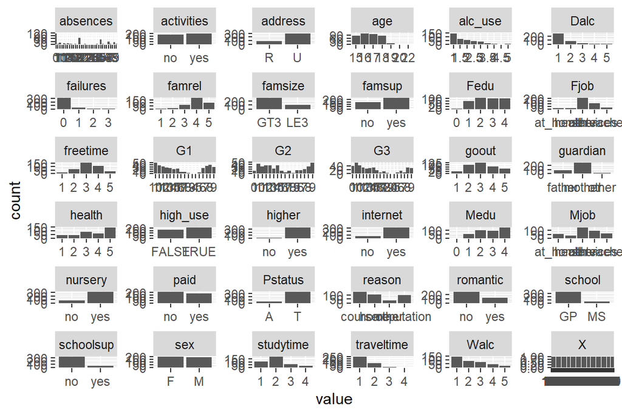

```r
gather(alc)%>%ggplot(aes(value))+facet_wrap("key", scales="free")+geom_bar()
```

### 2. Hypothesis

In order to study the relationship between high and low alcohol consumptions and variables, i am going to work folloing to hypothesis;

1. **Gender** - Males consume more alcohol than females.
2. **G1** - First period grade decreases with alcohol consumption.
3. **G2** - Second period grade decreases with alcohol consumption.
4. **G3** - Third period grade decreases with alcohol consumption.

I will take a look at each relationship followring to the hypothesis one by one p<-ggpairs(alc, mapping = aes(col=sex, alpha = 0.3), lower = list(combo = wrap(“facethist”, bins = 20))) p

#### Hypothesis 1 - **Gender**

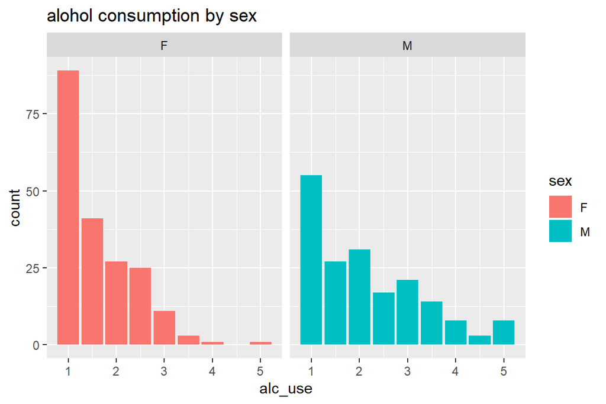

```r
g1 <- ggplot(data = alc, aes(x = alc_use, fill = sex))
g1 + geom_bar()+facet_wrap("sex") + ggtitle("alohol consumption by sex")
```

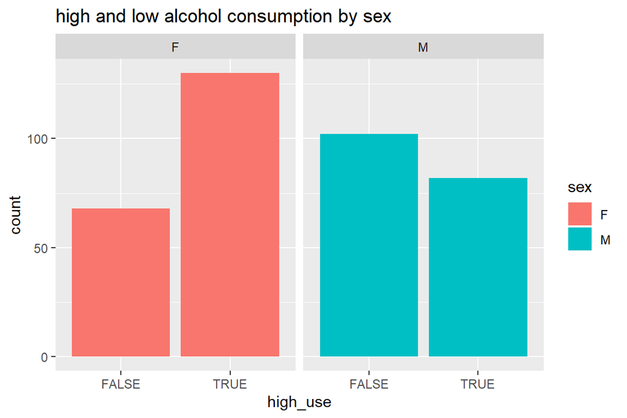

```r
g11<-ggplot(data=alc, aes(x=high_use, fill=sex))
g11+geom_bar()+facet_wrap("sex") + ggtitle("high and low alcohol consumption by sex")
```

#### Hypothesis 2 - **G1**

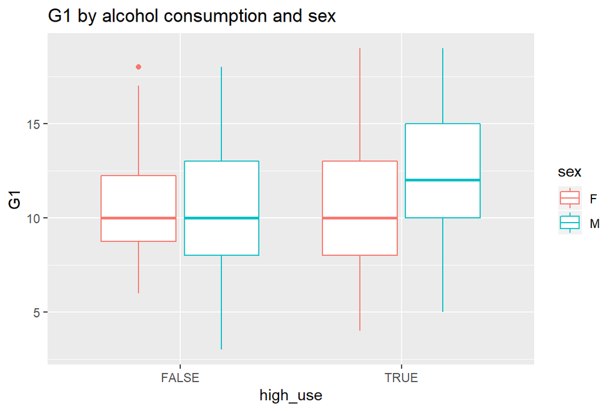

```r
g2 <- ggplot(data=alc, aes(x=high_use, y= G1, col=sex))
g2+geom_boxplot()+ggtitle("G1 by alcohol consumption and sex")
```

#### Hypothesis 3 - **G2**

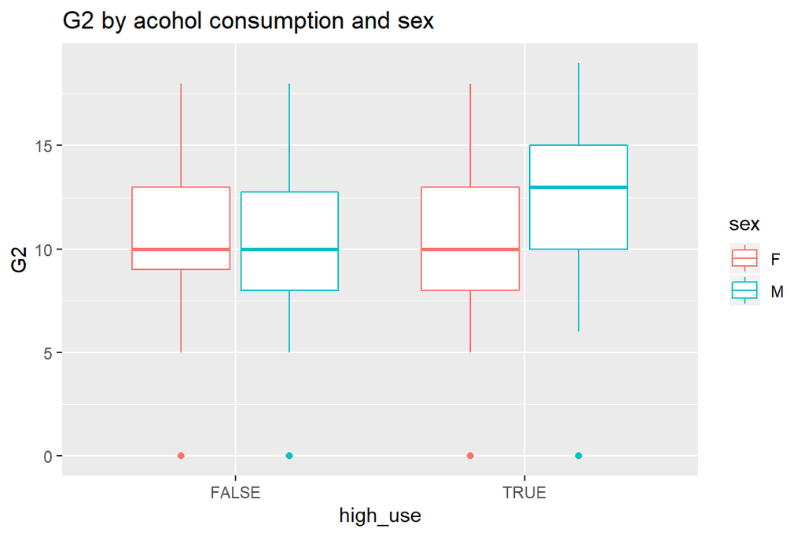

```r
g3<-ggplot(alc, aes(x=high_use, y=G2, col=sex))
g3+geom_boxplot()+ggtitle("G2 by acohol consumption and sex")
```

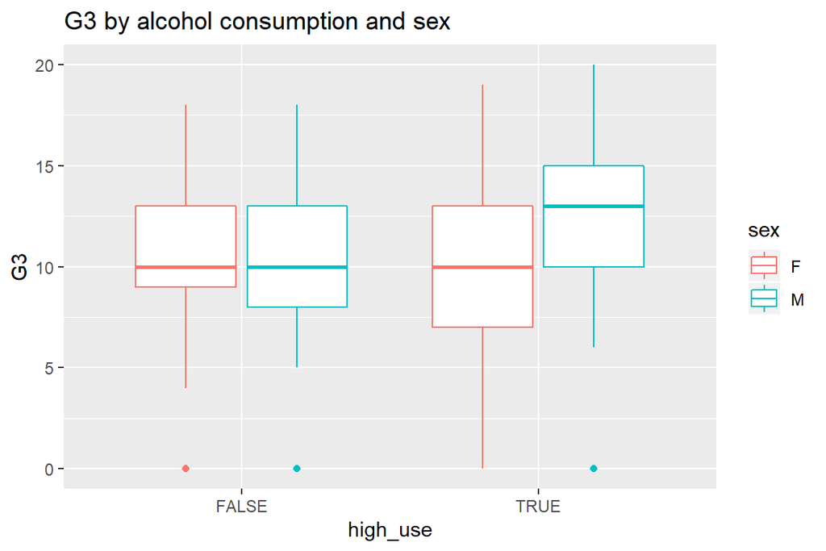

```r
g4<-ggplot(alc, aes(x=high_use, y=G3, col=sex))
g4+geom_boxplot()+ggtitle("G3 by alcohol consumption and sex")
```

### 3.Lostistic regression

From now, in order to interpret relationship between variables presumably relating to alcohol consumptions and alcohol consumption, we will deal with logistaic regression.

```r
m<-glm(high_use~sex+G1+G2+G3, data=alc, family="binomial")
summary(m)
```

```
##
## Call:
## glm(formula = high_use ~ sex + G1 + G2 + G3, family = "binomial",
##     data = alc)
##
## Deviance Residuals:
##     Min       1Q   Median       3Q      Max
## -1.7050  -1.1393   0.8236   1.0275   1.4369
##
## Coefficients:
##              Estimate Std. Error z value Pr(>|z|)
## (Intercept) -0.124551   0.377648  -0.330    0.742
## sexM        -0.929752   0.215442  -4.316 1.59e-05 ***
## G1           0.100421   0.063556   1.580    0.114
## G2           0.005342   0.076244   0.070    0.944
## G3          -0.032884   0.053600  -0.614    0.540
## ---
## Signif. codes:  0 '***' 0.001 '**' 0.01 '*' 0.05 '.' 0.1 ' ' 1
##
## (Dispersion parameter for binomial family taken to be 1)
##
##     Null deviance: 524.94  on 381  degrees of freedom
## Residual deviance: 502.43  on 377  degrees of freedom
## AIC: 512.43
##
## Number of Fisher Scoring iterations: 4
```

```r
coef(m)
```

```
##  (Intercept)         sexM           G1           G2           G3
## -0.124550963 -0.929752246  0.100420779  0.005341903 -0.032884237
```

```r
OR<-coef(m)%>%exp
OR
```

```
## (Intercept)        sexM          G1          G2          G3
##   0.8828933   0.3946515   1.1056360   1.0053562   0.9676506
```

```r
CI<-exp(confint(m))
CI
```

```
##                 2.5 %    97.5 %
## (Intercept) 0.4202206 1.8520181
## sexM        0.2575779 0.5999088
## G1          0.9774251 1.2553494
## G2          0.8649561 1.1681070
## G3          0.8686826 1.0737634
```

```r
cbind(OR, CI)
```

```
##                    OR     2.5 %    97.5 %
## (Intercept) 0.8828933 0.4202206 1.8520181
## sexM        0.3946515 0.2575779 0.5999088
## G1          1.1056360 0.9774251 1.2553494
## G2          1.0053562 0.8649561 1.1681070
## G3          0.9676506 0.8686826 1.0737634
```

#### Prediction power

```r
probabilities<-predict(m, type="response")
alc<-mutate(alc,probability=probabilities)
alc<-mutate(alc,prediction=probability>0.5)
select(alc,G2,G3, high_use, probability, prediction)%>% tail(10)
```

```
##     G2 G3 high_use probability prediction
## 373  5  0    FALSE   0.3953044      FALSE
## 374  5  5    FALSE   0.3567518      FALSE
## 375  9 10    FALSE   0.6454027       TRUE
## 376  5  6    FALSE   0.5762451       TRUE
## 377  5  0     TRUE   0.6468232       TRUE
## 378  9  8     TRUE   0.5898627       TRUE
## 379  5  0     TRUE   0.6235593       TRUE
## 380  5  0     TRUE   0.6235593       TRUE
## 381 16 16    FALSE   0.4777423      FALSE
## 382 12 10    FALSE   0.4466009      FALSE
```

#### 2x2 cross-tabulation and graphic representation

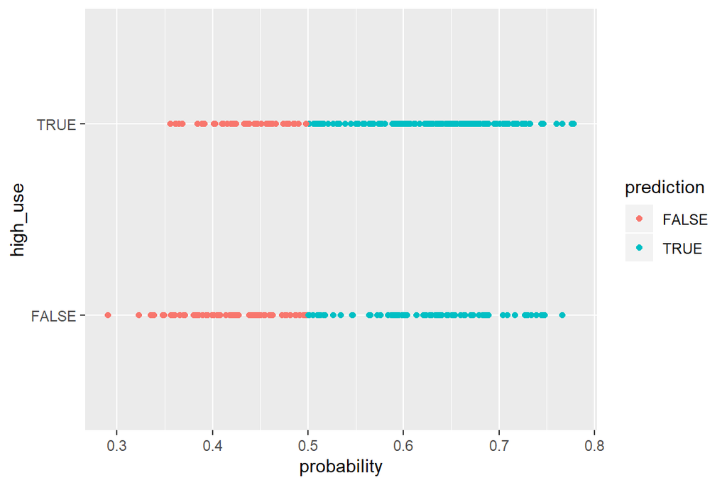

```r
g<-ggplot(alc,(aes(x=probability, y=high_use, col=prediction)))
g+geom_point()
```

```r
table(high_use=alc$high_use, prediction=alc$prediction)%>%prop.table()%>%addmargins()
```

```
##         prediction
## high_use     FALSE      TRUE       Sum
##    FALSE 0.2225131 0.2225131 0.4450262
##    TRUE  0.1492147 0.4057592 0.5549738
##    Sum   0.3717277 0.6282723 1.0000000
```

#### Exploring the training error

```r
loss_func<-function(class, prob){
  n_wrong <-abs(class - prob) > 0.5
  mean(n_wrong)
}
loss_func(class = alc$high_use, prob = alc$probability)
```

```
## [1] 0.3717277
```

#### 10-fold cross-validation (Bonus task)

```r
cv<-cv.glm(data=alc, cost=loss_func, glmfit = m, K=10)
cv$delta[1]
```

```
## [1] 0.3795812
```

#### Eventually, the prediction error with the 4 variables is **40%**.

# Clustering and classification (Exercise 4)

```r
library(MASS);library(tidyverse);library(corrplot)
data("Boston")
```

```r
str(Boston)
```

```
## 'data.frame':    506 obs. of  14 variables:
##  $ crim   : num  0.00632 0.02731 0.02729 0.03237 0.06905 ...
##  $ zn     : num  18 0 0 0 0 0 12.5 12.5 12.5 12.5 ...
##  $ indus  : num  2.31 7.07 7.07 2.18 2.18 2.18 7.87 7.87 7.87 7.87 ...
##  $ chas   : int  0 0 0 0 0 0 0 0 0 0 ...
##  $ nox    : num  0.538 0.469 0.469 0.458 0.458 0.458 0.524 0.524 0.524 0.524 ...
##  $ rm     : num  6.58 6.42 7.18 7 7.15 ...
##  $ age    : num  65.2 78.9 61.1 45.8 54.2 58.7 66.6 96.1 100 85.9 ...
##  $ dis    : num  4.09 4.97 4.97 6.06 6.06 ...
##  $ rad    : int  1 2 2 3 3 3 5 5 5 5 ...
##  $ tax    : num  296 242 242 222 222 222 311 311 311 311 ...
##  $ ptratio: num  15.3 17.8 17.8 18.7 18.7 18.7 15.2 15.2 15.2 15.2 ...
##  $ black  : num  397 397 393 395 397 ...
##  $ lstat  : num  4.98 9.14 4.03 2.94 5.33 ...
##  $ medv   : num  24 21.6 34.7 33.4 36.2 28.7 22.9 27.1 16.5 18.9 ...
```

```r
summary(Boston)
```

```
##       crim                zn             indus            chas
##  Min.   : 0.00632   Min.   :  0.00   Min.   : 0.46   Min.   :0.00000
##  1st Qu.: 0.08204   1st Qu.:  0.00   1st Qu.: 5.19   1st Qu.:0.00000
##  Median : 0.25651   Median :  0.00   Median : 9.69   Median :0.00000
##  Mean   : 3.61352   Mean   : 11.36   Mean   :11.14   Mean   :0.06917
##  3rd Qu.: 3.67708   3rd Qu.: 12.50   3rd Qu.:18.10   3rd Qu.:0.00000
##  Max.   :88.97620   Max.   :100.00   Max.   :27.74   Max.   :1.00000
##       nox               rm             age              dis
##  Min.   :0.3850   Min.   :3.561   Min.   :  2.90   Min.   : 1.130
##  1st Qu.:0.4490   1st Qu.:5.886   1st Qu.: 45.02   1st Qu.: 2.100
##  Median :0.5380   Median :6.208   Median : 77.50   Median : 3.207
##  Mean   :0.5547   Mean   :6.285   Mean   : 68.57   Mean   : 3.795
##  3rd Qu.:0.6240   3rd Qu.:6.623   3rd Qu.: 94.08   3rd Qu.: 5.188
##  Max.   :0.8710   Max.   :8.780   Max.   :100.00   Max.   :12.127
##       rad              tax           ptratio          black
##  Min.   : 1.000   Min.   :187.0   Min.   :12.60   Min.   :  0.32
##  1st Qu.: 4.000   1st Qu.:279.0   1st Qu.:17.40   1st Qu.:375.38
##  Median : 5.000   Median :330.0   Median :19.05   Median :391.44
##  Mean   : 9.549   Mean   :408.2   Mean   :18.46   Mean   :356.67
##  3rd Qu.:24.000   3rd Qu.:666.0   3rd Qu.:20.20   3rd Qu.:396.23
##  Max.   :24.000   Max.   :711.0   Max.   :22.00   Max.   :396.90
##      lstat            medv
##  Min.   : 1.73   Min.   : 5.00
##  1st Qu.: 6.95   1st Qu.:17.02
##  Median :11.36   Median :21.20
##  Mean   :12.65   Mean   :22.53
##  3rd Qu.:16.95   3rd Qu.:25.00
##  Max.   :37.97   Max.   :50.00
```

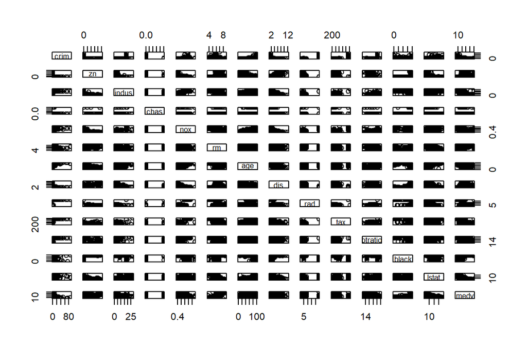

```r
pairs(Boston)
```

```r
cor_matrix<-cor(Boston)
cor_matrix%>%round(2)
```

```
##          crim    zn indus  chas   nox    rm   age   dis   rad   tax
## crim     1.00 -0.20  0.41 -0.06  0.42 -0.22  0.35 -0.38  0.63  0.58
## zn      -0.20  1.00 -0.53 -0.04 -0.52  0.31 -0.57  0.66 -0.31 -0.31
## indus    0.41 -0.53  1.00  0.06  0.76 -0.39  0.64 -0.71  0.60  0.72
## chas    -0.06 -0.04  0.06  1.00  0.09  0.09  0.09 -0.10 -0.01 -0.04
## nox      0.42 -0.52  0.76  0.09  1.00 -0.30  0.73 -0.77  0.61  0.67
## rm      -0.22  0.31 -0.39  0.09 -0.30  1.00 -0.24  0.21 -0.21 -0.29
## age      0.35 -0.57  0.64  0.09  0.73 -0.24  1.00 -0.75  0.46  0.51
## dis     -0.38  0.66 -0.71 -0.10 -0.77  0.21 -0.75  1.00 -0.49 -0.53
## rad      0.63 -0.31  0.60 -0.01  0.61 -0.21  0.46 -0.49  1.00  0.91
## tax      0.58 -0.31  0.72 -0.04  0.67 -0.29  0.51 -0.53  0.91  1.00
## ptratio  0.29 -0.39  0.38 -0.12  0.19 -0.36  0.26 -0.23  0.46  0.46
## black   -0.39  0.18 -0.36  0.05 -0.38  0.13 -0.27  0.29 -0.44 -0.44
## lstat    0.46 -0.41  0.60 -0.05  0.59 -0.61  0.60 -0.50  0.49  0.54
## medv    -0.39  0.36 -0.48  0.18 -0.43  0.70 -0.38  0.25 -0.38 -0.47
##         ptratio black lstat  medv
## crim       0.29 -0.39  0.46 -0.39
## zn        -0.39  0.18 -0.41  0.36
## indus      0.38 -0.36  0.60 -0.48
## chas      -0.12  0.05 -0.05  0.18
## nox        0.19 -0.38  0.59 -0.43
## rm        -0.36  0.13 -0.61  0.70
## age        0.26 -0.27  0.60 -0.38
## dis       -0.23  0.29 -0.50  0.25
## rad        0.46 -0.44  0.49 -0.38
## tax        0.46 -0.44  0.54 -0.47
## ptratio    1.00 -0.18  0.37 -0.51
## black     -0.18  1.00 -0.37  0.33
## lstat      0.37 -0.37  1.00 -0.74
## medv      -0.51  0.33 -0.74  1.00
```

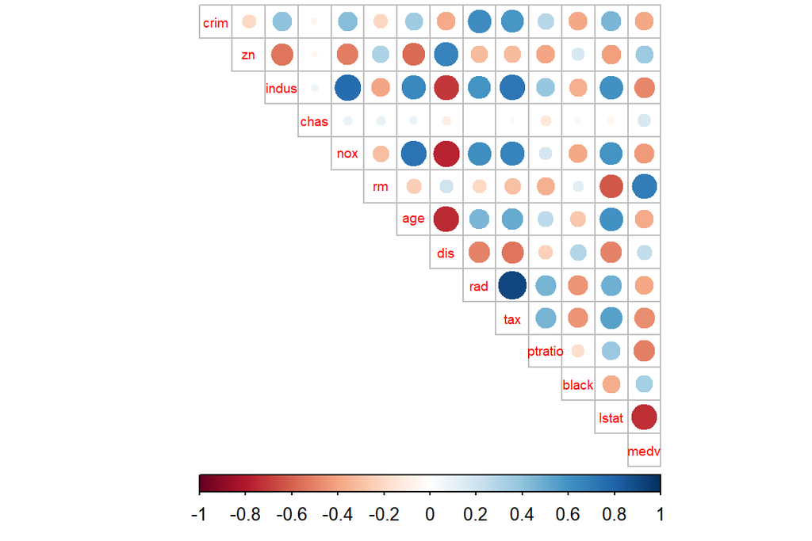

```r
corrplot(cor_matrix, method="circle", type="upper", cl.pos="b", tl.pos="d", tl.cex=0.6)
```

### Standardized data

```r
boston_scaled<-scale(Boston)
summary(boston_scaled)
```

```
##       crim                 zn               indus
##  Min.   :-0.419367   Min.   :-0.48724   Min.   :-1.5563
##  1st Qu.:-0.410563   1st Qu.:-0.48724   1st Qu.:-0.8668
##  Median :-0.390280   Median :-0.48724   Median :-0.2109
##  Mean   : 0.000000   Mean   : 0.00000   Mean   : 0.0000
##  3rd Qu.: 0.007389   3rd Qu.: 0.04872   3rd Qu.: 1.0150
##  Max.   : 9.924110   Max.   : 3.80047   Max.   : 2.4202
##       chas              nox                rm               age
##  Min.   :-0.2723   Min.   :-1.4644   Min.   :-3.8764   Min.   :-2.3331
##  1st Qu.:-0.2723   1st Qu.:-0.9121   1st Qu.:-0.5681   1st Qu.:-0.8366
##  Median :-0.2723   Median :-0.1441   Median :-0.1084   Median : 0.3171
##  Mean   : 0.0000   Mean   : 0.0000   Mean   : 0.0000   Mean   : 0.0000
##  3rd Qu.:-0.2723   3rd Qu.: 0.5981   3rd Qu.: 0.4823   3rd Qu.: 0.9059
##  Max.   : 3.6648   Max.   : 2.7296   Max.   : 3.5515   Max.   : 1.1164
##       dis               rad               tax             ptratio
##  Min.   :-1.2658   Min.   :-0.9819   Min.   :-1.3127   Min.   :-2.7047
##  1st Qu.:-0.8049   1st Qu.:-0.6373   1st Qu.:-0.7668   1st Qu.:-0.4876
##  Median :-0.2790   Median :-0.5225   Median :-0.4642   Median : 0.2746
##  Mean   : 0.0000   Mean   : 0.0000   Mean   : 0.0000   Mean   : 0.0000
##  3rd Qu.: 0.6617   3rd Qu.: 1.6596   3rd Qu.: 1.5294   3rd Qu.: 0.8058
##  Max.   : 3.9566   Max.   : 1.6596   Max.   : 1.7964   Max.   : 1.6372
##      black             lstat              medv
##  Min.   :-3.9033   Min.   :-1.5296   Min.   :-1.9063
##  1st Qu.: 0.2049   1st Qu.:-0.7986   1st Qu.:-0.5989
##  Median : 0.3808   Median :-0.1811   Median :-0.1449
##  Mean   : 0.0000   Mean   : 0.0000   Mean   : 0.0000
##  3rd Qu.: 0.4332   3rd Qu.: 0.6024   3rd Qu.: 0.2683
##  Max.   : 0.4406   Max.   : 3.5453   Max.   : 2.9865
```

### Covert matrix data to dafaframe

```r
class(boston_scaled)
```

```
## [1] "matrix"
```

```r
boston_scaled<-as.data.frame(boston_scaled)
```

### Create a catergorical variable with the variable “Crime”

```r
summary("crim")
```

```
##    Length     Class      Mode
##         1 character character
```

```r
bins<-quantile(boston_scaled$crim)
bins
```

```
##           0%          25%          50%          75%         100%
## -0.419366929 -0.410563278 -0.390280295  0.007389247  9.924109610
```

```r
crime<-cut(boston_scaled$crim, breaks=bins, include.lowest=TRUE, label=c("low","med_low","med_high", "high"))
crime
```

```
##   [1] low      low      low      low      low      low      med_low
##   [8] med_low  med_low  med_low  med_low  med_low  med_low  med_high
##  [15] med_high med_high med_high med_high med_high med_high med_high
##  [22] med_high med_high med_high med_high med_high med_high med_high
##  [29] med_high med_high med_high med_high med_high med_high med_high
##  [36] low      med_low  low      med_low  low      low      med_low
##  [43] med_low  med_low  med_low  med_low  med_low  med_low  med_low
##  [50] med_low  med_low  low      low      low      low      low
##  [57] low      low      med_low  med_low  med_low  med_low  med_low
##  [64] med_low  low      low      low      low      med_low  med_low
##  [71] med_low  med_low  med_low  med_low  low      med_low  med_low
##  [78] med_low  low      med_low  low      low      low      low
##  [85] low      low      low      low      low      low      low
##  [92] low      low      low      low      med_low  med_low  med_low
##  [99] low      low      med_low  med_low  med_low  med_low  med_low
```

[output cut: 59 more lines]

```r
table(crime)
```

```
## crime
##      low  med_low med_high     high
##      127      126      126      127
```

```r
boston_scaled<-dplyr::select(boston_scaled,-crim)
boston_scaled
```

[output not shown]

[output cut: 1506 more lines]

```r
boston_scaled<-data.frame(boston_scaled, crime)
```